```python
import warnings
warnings.simplefilter("ignore")
import pandas as pd
import numpy as np
import sklearn as sk
import matplotlib.pyplot as plt
import time
import os
import datetime
ts = '{:%Y%m%d%H%M%S}'.format(datetime.datetime.now())

from IPython.display import Image
from time import sleep
from sklearn.preprocessing import LabelEncoder
from sklearn.model_selection import train_test_split
from imblearn.over_sampling import SMOTE
from pandas import DataFrame, Series
from sklearn.preprocessing import StandardScaler
from sklearn.decomposition import PCA
from sklearn.tree import DecisionTreeClassifier
from sklearn.model_selection import GridSearchCV
from sklearn.metrics import classification_report
from sklearn.ensemble import RandomForestClassifier
from sklearn.ensemble import AdaBoostClassifier
from sklearn.ensemble import GradientBoostingClassifier
from sklearn.preprocessing import MinMaxScaler
from sklearn.neighbors import KNeighborsClassifier
from sklearn.svm import SVC
from sklearn.pipeline import Pipeline
from sklearn.naive_bayes import GaussianNB
from sklearn.model_selection import cross_val_score
from sklearn.model_selection import cross_val_predict
from sklearn.metrics import confusion_matrix
from sklearn.neural_network import MLPClassifier
from amb_sdk.sdk import DarwinSdk
from sklearn.metrics import r2_score

%matplotlib inline
```

# Cleaning Data

```python
data = pd.read_csv("speed-dating_raw.csv")
x = ['gender', 'race', 'race_o', 'field']
columns = list(data)

# Deleting bins
for column in columns:
    if column not in x and data[str(column)].dtype.name == 'object':
        del data[str(column)]

# Deleting useless columns
del data['has_null']
del data['wave']
del data['d_age']
del data['samerace']
del data['expected_happy_with_sd_people']
del data['expected_num_interested_in_me']
del data['expected_num_matches']
del data['like']
del data['guess_prob_liked']
del data['decision']
del data['decision_o']

# Replace age NA with mean
mean = round(data['age'].mean())
data['age'].fillna(mean, inplace = True)
mean = round(data['age_o'].mean())
data['age_o'].fillna(mean, inplace = True)

# Make sure difference in age is correct
data['age_d'] = (data['age'] - data['age_o'])
data['age_d_abs'] = data['age_d'].abs()

# Replace race NA with other
data['race'].fillna('other', inplace= True)
data['race_o'].fillna('other', inplace = True)

# Verifying that same_race is correct with replaced race
data['same_race'] = (data['race'] == data['race_o'])

# Replace NA with 0 for preferences
preferences = ['pref_o_attractive', 'pref_o_sincere', 'pref_o_intelligence', 'pref_o_funny', 'pref_o_ambitious', 'pref_o_shared_interests']
for pref in preferences:
    data[pref].fillna(0, inplace = True)

# Renaming column names
data.rename(columns = {'importance_same_race':'same_race_i',
                       'importance_same_religion': 'same_religion_i',
                       'pref_o_attractive':'attractive_o_i',
                       'pref_o_sincere':'sincere_o_i',
                       'pref_o_intelligence':'intelligence_o_i',
                       'pref_o_funny':'funny_o_i',
                       'pref_o_ambitious':'ambitious_o_i',
                       'pref_o_shared_interests':'shared_interests_o_i',
                       'attractive_important':'attractive_i',
                       'sincere_important': 'sincere_i',
                       'intellicence_important': 'intelligence_i',
                       'funny_important':'funny_i',
                       'ambtition_important':'ambitious_i',
                       'shared_interests_important':'shared_interests_i',
                       'ambition':'ambitious',
                       'sinsere_o': 'sincere_o',
                       'ambitous_o':'ambitious_o',
                       'ambition_partner':'ambitious_partner'}, inplace = True)

# Making sure that opposite's importance columns add up to 100
data['o_i'] = data['attractive_o_i'] + data['sincere_o_i'] + data['intelligence_o_i'] + data['funny_o_i'] + data['ambitious_o_i'] + data['shared_interests_o_i']
data['attractive_o_i'] = (data['attractive_o_i'] / data['o_i'])
data['sincere_o_i'] = (data['sincere_o_i'] / data['o_i'])
data['intelligence_o_i'] = (data['intelligence_o_i'] / data['o_i'])
data['funny_o_i'] = (data['funny_o_i'] / data['o_i'])
data['ambitious_o_i'] = (data['ambitious_o_i'] / data['o_i'])
data['shared_interests_o_i'] = (data['shared_interests_o_i'] / data['o_i'])

# Making sure that my importance columns add up to 100
data['i'] = data['attractive_i'] + data['sincere_i'] + data['intelligence_i'] + data['funny_i'] + data['ambitious_i'] + data['shared_interests_i']
data['attractive_i'] = (data['attractive_i'] / data['i'])
data['sincere_i'] = (data['sincere_i'] / data['i'])
data['intelligence_i'] = (data['intelligence_i'] / data['i'])
data['funny_i'] = (data['funny_i'] / data['i'])
data['ambitious_i'] = (data['ambitious_i'] / data['i'])
data['shared_interests_i'] = (data['shared_interests_i'] / data['i'])

del data['o_i']
del data['i']

# Filling in data that are empty
temp = ['attractive_o_i', 'sincere_o_i', 'intelligence_o_i', 'funny_o_i', 'ambitious_o_i', 'shared_interests_o_i', 'attractive_i', 'sincere_i', 'intelligence_i', 'funny_i', 'ambitious_i', 'shared_interests_i']
for t in temp:
    data[t].fillna((1.0 / 6.0), inplace = True)

# Replacing same_race_i & same_religion_i with mean (importance)
mean = data['same_race_i'].mean()
data['same_race_i'].fillna(round(mean), inplace = True)

mean = data['same_religion_i'].mean()
data['same_religion_i'].fillna(round(mean), inplace = True)

# One Hot Encoding of categorical data
data = pd.concat([data, pd.get_dummies(data['gender'], prefix = 'gender')], axis = 1)
data = pd.concat([data, pd.get_dummies(data['race'], prefix = 'race')], axis = 1)
data = pd.concat([data, pd.get_dummies(data['race_o'], prefix = 'race_o')], axis = 1)
data = pd.concat([data, pd.get_dummies(data['field'], prefix = 'field')], axis = 1)

del data['gender']
del data['race']
del data['race_o']
del data['field']

# Label Encoding
le = LabelEncoder()
data['same_race'] = le.fit_transform(data['same_race'])

# Fill NA's with mean
mean = data['attractive_o'].mean()
data['attractive_o'].fillna(round(mean), inplace = True)
mean = data['sincere_o'].mean()
data['sincere_o'].fillna(round(mean), inplace = True)
mean = data['intelligence_o'].mean()
data['intelligence_o'].fillna(round(mean), inplace = True)
mean = data['funny_o'].mean()
data['funny_o'].fillna(round(mean), inplace = True)
mean = data['ambitious_o'].mean()
data['ambitious_o'].fillna(round(mean), inplace = True)
mean = data['shared_interests_o'].mean()
data['shared_interests_o'].fillna(round(mean), inplace = True)
mean = data['attractive'].mean()
data['attractive'].fillna(round(mean), inplace = True)
mean = data['sincere'].mean()
data['sincere'].fillna(round(mean), inplace = True)
mean = data['intelligence'].mean()
data['intelligence'].fillna(round(mean), inplace = True)
mean = data['funny'].mean()
data['funny'].fillna(round(mean), inplace = True)
mean = data['ambitious'].mean()
data['ambitious'].fillna(round(mean), inplace = True)
mean = data['attractive_partner'].mean()
data['attractive_partner'].fillna(round(mean), inplace = True)
mean = data['sincere_partner'].mean()
data['sincere_partner'].fillna(round(mean), inplace = True)
mean = data['intelligence_partner'].mean()
data['intelligence_partner'].fillna(round(mean), inplace = True)
mean = data['funny_partner'].mean()
data['funny_partner'].fillna(round(mean), inplace = True)
mean = data['ambitious_partner'].mean()
data['ambitious_partner'].fillna(round(mean), inplace = True)
mean = data['shared_interests_partner'].mean()
data['shared_interests_partner'].fillna(round(mean), inplace = True)
mean = data['met'].mean()
data['met'].fillna(round(mean), inplace = True)

# Delete rows with NA's for interests correlate
data = data.dropna(axis = 0, subset = ['interests_correlate'])

print(data.shape)
data.head()
```

```
(8220, 287)
```

|  | age | age_o | same_race_i | same_religion_i | attractive_o_i | sincere_o_i | intelligence_o_i | funny_o_i | ambitious_o_i | shared_interests_o_i | ... | field_tc [health ed] | field_teaching of english | field_tesol | field_theater | field_theatre management & producing | field_theory | field_undergrad - gs | field_urban planning | field_working | field_writing: literary nonfiction |
| --- | --- | --- | --- | --- | --- | --- | --- | --- | --- | --- | --- | --- | --- | --- | --- | --- | --- | --- | --- | --- | --- |
| 0 | 21.0 | 27.0 | 2.0 | 4.0 | 0.35 | 0.20 | 0.20 | 0.20 | 0.00 | 0.05 | ... | 0 | 0 | 0 | 0 | 0 | 0 | 0 | 0 | 0 | 0 |
| 1 | 21.0 | 22.0 | 2.0 | 4.0 | 0.60 | 0.00 | 0.00 | 0.40 | 0.00 | 0.00 | ... | 0 | 0 | 0 | 0 | 0 | 0 | 0 | 0 | 0 | 0 |
| 2 | 21.0 | 22.0 | 2.0 | 4.0 | 0.19 | 0.18 | 0.19 | 0.18 | 0.14 | 0.12 | ... | 0 | 0 | 0 | 0 | 0 | 0 | 0 | 0 | 0 | 0 |
| 3 | 21.0 | 23.0 | 2.0 | 4.0 | 0.30 | 0.05 | 0.15 | 0.40 | 0.05 | 0.05 | ... | 0 | 0 | 0 | 0 | 0 | 0 | 0 | 0 | 0 | 0 |
| 4 | 21.0 | 24.0 | 2.0 | 4.0 | 0.30 | 0.10 | 0.20 | 0.10 | 0.10 | 0.20 | ... | 0 | 0 | 0 | 0 | 0 | 0 | 0 | 0 | 0 | 0 |

5 rows × 287 columns

# Feature Engineering

```python
# Difference between opposite's and my importance
data['attractive_i_d'] = (data['attractive_i'] - data['attractive_o_i'])
data['sincere_i_d'] = (data['sincere_i'] - data['sincere_o_i'])
data['intelligence_i_d'] = (data['intelligence_i'] - data['intelligence_o_i'])
data['funny_i_d'] = (data['funny_i'] - data['funny_o_i'])
data['ambitious_i_d'] = (data['ambitious_i'] - data['ambitious_o_i'])
data['shared_interests_i_d'] = (data['shared_interests_i'] - data['shared_interests_o_i'])

# Absolute difference of importance
data['attractive_i_d_abs'] = data['attractive_i_d'].abs()
data['sincere_i_d_abs'] = data['sincere_i_d'].abs()
data['intelligence_i_d_abs'] = data['intelligence_i_d'].abs()
data['funny_i_d_abs'] = data['funny_i_d'].abs()
data['ambitious_i_d_abs'] = data['ambitious_i_d'].abs()
data['shared_interests_i_d_abs'] = data['shared_interests_i_d'].abs()

# Difference between opposite's and my rating of me
data['attractive_d'] = (data['attractive'] - data['attractive_o'])
data['sincere_d'] = (data['sincere'] - data['sincere_o'])
data['intelligence_d'] = (data['intelligence'] - data['intelligence_o'])
data['funny_d'] = (data['funny'] - data['funny_o'])
data['ambitious_d'] = (data['ambitious'] - data['ambitious_o'])
data['shared_interests_d'] = (data['shared_interests_partner'] - data['shared_interests_o'])

# Absolute difference of rating
data['attractive_d_abs'] = data['attractive_d'].abs()
data['sincere_d_abs'] = data['sincere_d'].abs()
data['intelligence_d_abs'] = data['intelligence_d'].abs()
data['funny_d_abs'] = data['funny_d'].abs()
data['ambitious_d_abs'] = data['ambitious_d'].abs()
data['shared_interests_d_abs'] = data['shared_interests_d'].abs()

# Changing from [1-10] scale to percentage for opposite's rating
data['o'] = data['attractive_o'] + data['sincere_o'] + data['intelligence_o'] + data['funny_o'] + data['ambitious_o'] + data['shared_interests_o']
data['attractive_o_n'] = (data['attractive_o'] / data['o'])
data['sincere_o_n'] = (data['sincere_o'] / data['o'])
data['intelligence_o_n'] = (data['intelligence_o'] / data['o'])
data['funny_o_n'] = (data['funny_o'] / data['o'])
data['ambitious_o_n'] = (data['ambitious_o'] / data['o'])
data['shared_interests_o_n'] = (data['shared_interests_o'] / data['o'])

# Changing from [1-10] scale to percentage for my rating of opposite
data['p'] = data['attractive_partner'] + data['sincere_partner'] + data['intelligence_partner'] + data['funny_partner'] + data['ambitious_partner'] + data['shared_interests_partner']
data['attractive_p_n'] = (data['attractive_partner'] / data['p'])
data['sincere_p_n'] = (data['sincere_partner'] / data['p'])
data['intelligence_p_n'] = (data['intelligence_partner'] / data['p'])
data['funny_p_n'] = (data['funny_partner'] / data['p'])
data['ambitious_p_n'] = (data['ambitious_partner'] / data['p'])
data['shared_interests_p_n'] = (data['shared_interests_partner'] / data['p'])

del data['o']
del data['p']

# Filling in blanks with 0
preferences = ['attractive_o_n', 'sincere_o_n', 'intelligence_o_n', 'funny_o_n', 'ambitious_o_n', 'shared_interests_o_n', 'attractive_p_n', 'sincere_p_n', 'intelligence_p_n', 'funny_p_n', 'ambitious_p_n', 'shared_interests_p_n']
for pref in preferences:
    data[pref].fillna(0, inplace = True)

# Difference of rating percentage
data['d'] = data['attractive_d_abs'] + data['sincere_d_abs'] + data['intelligence_d_abs'] + data['funny_d_abs'] + data['ambitious_d_abs'] + data['shared_interests_d_abs']
data['attractive_d_n'] = (data['attractive_d'] / data['d'])
data['sincere_d_n'] = (data['sincere_d'] / data['d'])
data['intelligence_d_n'] = (data['intelligence_d'] / data['d'])
data['funny_d_n'] = (data['funny_d'] / data['d'])
data['ambitious_d_n'] = (data['ambitious_d'] / data['d'])
data['shared_interests_d_n'] = (data['shared_interests_d'] / data['d'])

del data['d']

# Absolute difference of rating percentage
data['attractive_d_n_abs'] = data['attractive_d_n'].abs()
data['sincere_d_n_abs'] = data['sincere_d_n'].abs()
data['intelligence_d_n_abs'] = data['intelligence_d_n'].abs()
data['funny_d_n_abs'] = data['funny_d_n'].abs()
data['ambitious_d_n_abs'] = data['ambitious_d_n'].abs()
data['shared_interests_d_n_abs'] = data['shared_interests_d_n'].abs()

# Difference between opposite's importance and their rating of me
data['attractive_oi_o_d_n'] = (data['attractive_o_i'] - data['attractive_o_n'])
data['sincere_oi_o_d_n'] = (data['sincere_o_i'] - data['sincere_o_n'])
data['intelligence_oi_o_d_n'] = (data['intelligence_o_i'] - data['intelligence_o_n'])
data['funny_oi_o_d_n'] = (data['funny_o_i'] - data['funny_o_n'])
data['ambitious_oi_o_d_n'] = (data['ambitious_o_i'] - data['ambitious_o_n'])
data['shared_interests_oi_o_d_n'] = (data['shared_interests_o_i'] - data['shared_interests_o_n'])

# Absolute difference of opposite's importance and their rating of me
data['attractive_oi_o_d_n_abs'] = data['attractive_oi_o_d_n'].abs()
data['sincere_oi_o_d_n_abs'] = data['sincere_oi_o_d_n'].abs()
data['intelligence_oi_o_d_n_abs'] = data['intelligence_oi_o_d_n'].abs()
data['funny_oi_o_d_n_abs'] = data['funny_oi_o_d_n'].abs()
data['ambitious_oi_o_d_n_abs'] = data['ambitious_oi_o_d_n'].abs()
data['shared_interests_oi_o_d_n_abs'] = data['shared_interests_oi_o_d_n'].abs()

# Difference between my importance and my rating of opposite
data['attractive_i_p_d_n'] = (data['attractive_i'] - data['attractive_p_n'])
data['sincere_i_p_d_n'] = (data['sincere_i'] - data['sincere_p_n'])
data['intelligence_i_p_d_n'] = (data['intelligence_i'] - data['intelligence_p_n'])
data['funny_i_p_d_n'] = (data['funny_i'] - data['funny_p_n'])
data['ambitious_i_p_d_n'] = (data['ambitious_i'] - data['ambitious_p_n'])
data['shared_interests_i_p_d_n'] = (data['shared_interests_i'] - data['shared_interests_p_n'])

# Absolute difference of my importance and my rating of opposite
data['attractive_i_p_d_n_abs'] = data['attractive_i_p_d_n'].abs()
data['sincere_i_p_d_n_abs'] = data['sincere_i_p_d_n'].abs()
data['intelligence_i_p_d_n_abs'] = data['intelligence_i_p_d_n'].abs()
data['funny_i_p_d_n_abs'] = data['funny_i_p_d_n'].abs()
data['ambitious_i_p_d_n_abs'] = data['ambitious_i_p_d_n'].abs()
data['shared_interests_i_p_d_n_abs'] = data['shared_interests_i_p_d_n'].abs()

# Changing from [1-10] scale to percentage for activities
data['a'] = data['sports'] + data['tvsports'] + data['exercise'] + data['dining'] + data['museums'] + data['art'] + data['hiking'] + data['gaming'] + data['clubbing'] + data['reading'] + data['tv'] + data['theater'] + data['movies'] + data['concerts'] + data['music'] + data['shopping'] + data['yoga']
data['sports_n'] = (data['sports'] / data['a'])
data['tvsports_n'] = (data['tvsports'] / data['a'])
data['exercise_n'] = (data['exercise'] / data['a'])
data['dining_n'] = (data['dining'] / data['a'])
data['museums_n'] = (data['museums'] / data['a'])
data['art_n'] = (data['art'] / data['a'])
data['hiking_n'] = (data['hiking'] / data['a'])
data['gaming_n'] = (data['gaming'] / data['a'])
data['clubbing_n'] = (data['clubbing'] / data['a'])
data['reading_n'] = (data['reading'] / data['a'])
data['tv_n'] = (data['tv'] / data['a'])
data['theater_n'] = (data['theater'] / data['a'])
data['movies_n'] = (data['movies'] / data['a'])
data['concerts_n'] = (data['concerts'] / data['a'])
data['music_n'] = (data['music'] / data['a'])
data['shopping_n'] = (data['shopping'] / data['a'])
data['yoga_n'] = (data['yoga'] / data['a'])

del data['a']

data.to_csv('Speed_Dating_Clean_noSMOTE.csv', index = False)

# Create train and test data for Darwin (no SMOTE)
data_Y = data['match']
data_X = data.drop(['match'], axis = 1)

train_X, test_X, train_Y, test_Y = train_test_split(data_X, data_Y, test_size = 0.20, random_state = 11)
train_data = pd.concat([train_X, train_Y], axis = 1)
train_data.to_csv('Speed_Dating_Clean_noSMOTE_train.csv', index = False)
test_data = pd.concat([test_X, test_Y], axis = 1)
test_data.to_csv('Speed_Dating_Clean_noSMOTE_test.csv', index = False)
```

# SMOTE

```python
data_Y = data['match']
data_X = data.drop(['match'], axis = 1)

sm = SMOTE(sampling_strategy = 'minority', random_state = 11)
smote_X, smote_Y = sm.fit_sample(data_X, data_Y)

print(smote_X.shape)
print(smote_Y.shape)
smote_X = DataFrame(smote_X, columns = data_X.columns)
smote_Y = Series(smote_Y, name = 'match')
data = pd.concat([smote_X, smote_Y], axis = 1)
data.head()

data.to_csv('Speed_Dating_Clean_SMOTE.csv', index = False)

# Create train and test data for Darwin (SMOTE)
data_Y = data['match']
data_X = data.drop(['match'], axis = 1)

train_X, test_X, train_Y, test_Y = train_test_split(data_X, data_Y, test_size = 0.20, random_state = 11)
train_data = pd.concat([train_X, train_Y], axis = 1)
train_data.to_csv('Speed_Dating_Clean_SMOTE_train.csv', index = False)
test_data = pd.concat([test_X, test_Y], axis = 1)
test_data.to_csv('Speed_Dating_Clean_SMOTE_test.csv', index = False)
```

```
(13740, 375)
(13740,)
```

# Darwin (SMOTE)

```python
ds = DarwinSdk()
ds.set_url('https://amb-demo-api.sparkcognition.com/v1/')
status, msg = ds.auth_login_user('EMMIECHNG@UTEXAS.EDU', 'QMCZgepW6u')

if not status:
    print(msg)
```

```python
dataset_train = 'Speed_Dating_Clean_SMOTE_train.csv'
dataset_test = 'Speed_Dating_Clean_SMOTE_test.csv'
```

**Upload datasets**

```python
# Upload train dataset to Darwin
data_SMOTE_train = pd.read_csv("Speed_Dating_Clean_SMOTE_train.csv")
status, dataset = ds.upload_dataset("Speed_Dating_Clean_SMOTE_train.csv")

if not status:
    print(dataset)
```

```python
# Upload test dataset to Darwin
data_SMOTE_test = pd.read_csv("Speed_Dating_Clean_SMOTE_test.csv")
status, dataset = ds.upload_dataset("Speed_Dating_Clean_SMOTE_test.csv")

if not status:
    print(dataset)
```

```python
ds.lookup_dataset()
```

```
(True,
 [{'name': 'Speed_Dating_Clean_SMOTE_train.csv',
   'mbytes': 30.262596130371094,
   'minimum_recommeded_train_time': '5 minutes',
   'updated_at': '2019-04-17T20:58:00.874245',
   'categorical': None,
   'sequential': None,
   'imbalanced': None},
  {'name': 'Speed_Dating_Clean_SMOTE_test.csv',
   'mbytes': 7.55277156829834,
   'minimum_recommeded_train_time': '5 minutes',
   'updated_at': '2019-04-17T20:58:42.347727',
   'categorical': None,
   'sequential': None,
   'imbalanced': None}])
```

**Clean datasets**

```python
# Clean train dataset on Darwin
target = "match"
status, job_id = ds.clean_data(dataset_train, target = target)

if status:
    ds.wait_for_job(job_id['job_name'])
else:
    print(job_id)
```

```
{'status': 'Taken', 'starttime': '2019-04-17T20:58:43.647439', 'endtime': None, 'percent_complete': 0, 'job_type': 'CleanDataTiny', 'loss': None, 'generations': None, 'dataset_names': ['Speed_Dating_Clean_SMOTE_train.csv'], 'artifact_names': ['09b4278228cb407f9dda18d484f0ab47'], 'model_name': None, …
{'status': 'Running', 'starttime': '2019-04-17T20:58:43.647439', 'endtime': None, 'percent_complete': 0, 'job_type': 'CleanDataTiny', 'loss': None, 'generations': None, 'dataset_names': ['Speed_Dating_Clean_SMOTE_train.csv'], 'artifact_names': ['09b4278228cb407f9dda18d484f0ab47'], 'model_name': None…
{'status': 'Running', 'starttime': '2019-04-17T20:58:43.647439', 'endtime': None, 'percent_complete': 0, 'job_type': 'CleanDataTiny', 'loss': None, 'generations': None, 'dataset_names': ['Speed_Dating_Clean_SMOTE_train.csv'], 'artifact_names': ['09b4278228cb407f9dda18d484f0ab47'], 'model_name': None…
{'status': 'Complete', 'starttime': '2019-04-17T20:58:43.647439', 'endtime': '2019-04-17T20:59:14.50013', 'percent_complete': 100, 'job_type': 'CleanDataTiny', 'loss': None, 'generations': None, 'dataset_names': ['Speed_Dating_Clean_SMOTE_train.csv'], 'artifact_names': ['09b4278228cb407f9dda18d484f0…
```

```python
# Clean test dataset on Darwin
target = "match"
status, job_id = ds.clean_data(dataset_test, target = target)

if status:
    ds.wait_for_job(job_id['job_name'])
else:
    print(job_id)
```

```
{'status': 'Taken', 'starttime': '2019-04-17T20:59:30.220999', 'endtime': None, 'percent_complete': 0, 'job_type': 'CleanDataTiny', 'loss': None, 'generations': None, 'dataset_names': ['Speed_Dating_Clean_SMOTE_test.csv'], 'artifact_names': ['20b085177ece4d5e898030e3ce68f64e'], 'model_name': None, '…
{'status': 'Running', 'starttime': '2019-04-17T20:59:30.220999', 'endtime': None, 'percent_complete': 0, 'job_type': 'CleanDataTiny', 'loss': None, 'generations': None, 'dataset_names': ['Speed_Dating_Clean_SMOTE_test.csv'], 'artifact_names': ['20b085177ece4d5e898030e3ce68f64e'], 'model_name': None,…
{'status': 'Complete', 'starttime': '2019-04-17T20:59:30.220999', 'endtime': '2019-04-17T20:59:46.011892', 'percent_complete': 100, 'job_type': 'CleanDataTiny', 'loss': None, 'generations': None, 'dataset_names': ['Speed_Dating_Clean_SMOTE_test.csv'], 'artifact_names': ['20b085177ece4d5e898030e3ce68…
```

**Create model**

```python
# Create Darwin model
model = target + "_model" + ts
status, job_id = ds.create_model(dataset_names = dataset_train,
                                 model_name = model,
                                 max_train_time = '00:05')

if status:
    ds.wait_for_job(job_id['job_name'])
else:
    print(job_id)
```

[output not shown]

[output cut: 8 more lines]

```python
# Extra training for Darwin model
status, job_id = ds.resume_training_model(dataset_names = dataset_train,
                                         model_name = model,
                                         max_train_time = '00:05')

if status:
    ds.wait_for_job(job_id['job_name'])
else:
    print(job_id)
```

[output not shown]

[output cut: 9 more lines]

# Best model decided by Darwin

**Analyze model**

```python
# Analyze Darwin model
status, artifact = ds.analyze_model(model)
sleep(1)
if status:
    ds.wait_for_job(artifact['job_name'])
else:
    print(artifact)
status, feature_importance = ds.download_artifact(artifact['artifact_name'])
```

```
{'status': 'Running', 'starttime': '2019-04-17T21:11:53.759455', 'endtime': None, 'percent_complete': 0, 'job_type': 'AnalyzeModel', 'loss': 0.26659178733825684, 'generations': 7, 'dataset_names': None, 'artifact_names': ['99bd9ec7837c47de8b8907efcc26ae3c'], 'model_name': 'match_model20190418095459'…
{'status': 'Complete', 'starttime': '2019-04-17T21:11:53.759455', 'endtime': '2019-04-17T21:11:57.624245', 'percent_complete': 100, 'job_type': 'AnalyzeModel', 'loss': 0.26659178733825684, 'generations': 7, 'dataset_names': None, 'artifact_names': ['99bd9ec7837c47de8b8907efcc26ae3c'], 'model_name': …
```

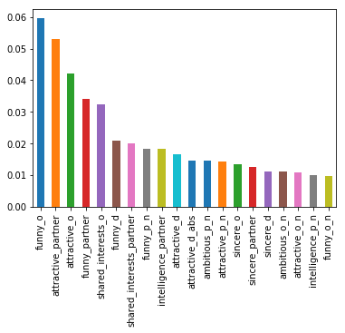

```python
feature_importance[:20].plot.bar()
```

**Prediction on training dataset**

```python
status, artifact = ds.run_model(dataset_train, model)
sleep(1)
ds.wait_for_job(artifact['job_name'])

status, prediction = ds.download_artifact(artifact['artifact_name'])
print("\n", prediction.head())
```

```
{'status': 'Running', 'starttime': '2019-04-17T21:12:12.717839', 'endtime': None, 'percent_complete': 0, 'job_type': 'RunModel', 'loss': 0.26659178733825684, 'generations': 7, 'dataset_names': ['Speed_Dating_Clean_SMOTE_train.csv'], 'artifact_names': ['8607fcf040ba43628f46b59529fd60b8'], 'model_name…
{'status': 'Complete', 'starttime': '2019-04-17T21:12:12.717839', 'endtime': '2019-04-17T21:12:16.277496', 'percent_complete': 100, 'job_type': 'RunModel', 'loss': 0.26659178733825684, 'generations': 7, 'dataset_names': ['Speed_Dating_Clean_SMOTE_train.csv'], 'artifact_names': ['8607fcf040ba43628f46…

    match    prob_0    prob_1
0      1  0.005518  0.994482
1      1  0.016885  0.983115
2      0  0.999708  0.000292
3      0  0.834926  0.165074
4      0  0.986597  0.013403
```

**Create plots comparing predictions with actual target**

```python
plt.plot(data_SMOTE_train[target], prediction[target], '.')
plt.plot([0,2.3e7],[0,2.3e7],'--k')
print('R^2 : ', r2_score(data_SMOTE_train[target], prediction[target]))
```

```
R^2 :  0.8569868806249564
```

```
               precision    recall  f1-score   support

           0       0.96      0.97      0.96      5494
           1       0.97      0.96      0.96      5498

   micro avg       0.96      0.96      0.96     10992
   macro avg       0.96      0.96      0.96     10992
weighted avg       0.96      0.96      0.96     10992
```

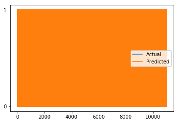

```python
unq = prediction[target].unique()[::-1]
p = np.zeros((len(prediction),))
a = np.zeros((len(prediction),))
for i,q in enumerate(unq):
    p += i*(prediction[target] == q).values
    a += i*(data_SMOTE_train[target] == q).values
#Plot predictions vs actual
plt.plot(a)
plt.plot(p)
plt.legend(['Actual','Predicted'])
plt.yticks([i for i in range(len(unq))],[q for q in unq]);
print("\n", classification_report(data_SMOTE_train[target], prediction[target]))
```

**Prediction on testing data**

```python
status, artifact = ds.run_model(dataset_test, model)
sleep(1)
ds.wait_for_job(artifact['job_name'])

status, prediction = ds.download_artifact(artifact['artifact_name'])
print("\n", prediction.head())
```

```
{'status': 'Running', 'starttime': '2019-04-17T21:12:32.143049', 'endtime': None, 'percent_complete': 0, 'job_type': 'RunModel', 'loss': 0.26659178733825684, 'generations': 7, 'dataset_names': ['Speed_Dating_Clean_SMOTE_test.csv'], 'artifact_names': ['97dcad05f17447a8ae4948bb854494c8'], 'model_name'…
{'status': 'Complete', 'starttime': '2019-04-17T21:12:32.143049', 'endtime': '2019-04-17T21:12:33.862991', 'percent_complete': 100, 'job_type': 'RunModel', 'loss': 0.26659178733825684, 'generations': 7, 'dataset_names': ['Speed_Dating_Clean_SMOTE_test.csv'], 'artifact_names': ['97dcad05f17447a8ae494…

    match    prob_0    prob_1
0      0  0.999931  0.000069
1      0  0.994718  0.005282
2      1  0.073136  0.926864
3      0  0.849925  0.150075
4      0  0.720189  0.279811
```

**Create plots comparing predictions with actual target**

```python
plt.plot(data_SMOTE_test[target], prediction[target], '.')
plt.plot([0,2.3e7],[0,2.3e7],'--k')
print('R^2 : ', r2_score(data_SMOTE_test[target], prediction[target]))
```

```
R^2 :  -0.45851837412705954
```

```
               precision    recall  f1-score   support

           0       0.60      0.82      0.69      1376
           1       0.72      0.45      0.55      1372

   micro avg       0.64      0.64      0.64      2748
   macro avg       0.66      0.64      0.62      2748
weighted avg       0.66      0.64      0.62      2748
```

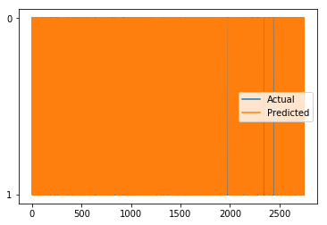

```python
unq = prediction[target].unique()[::-1]
p = np.zeros((len(prediction),))
a = np.zeros((len(prediction),))
for i,q in enumerate(unq):
    p += i*(prediction[target] == q).values
    a += i*(data_SMOTE_test[target] == q).values
#Plot predictions vs actual
plt.plot(a)
plt.plot(p)
plt.legend(['Actual','Predicted'])
plt.yticks([i for i in range(len(unq))],[q for q in unq]);
print("\n", classification_report(data_SMOTE_test[target], prediction[target]))
```

**Model Darwin used**

```python
status, model_type = ds.lookup_model_name(model)
print(model_type)
```

```
{'type': 'Supervised', 'updated_at': '2019-04-17T21:11:38.110426', 'trained_on': ['Speed_Dating_Clean_SMOTE_train.csv'], 'loss': 0.26659178733825684, 'generations': 7, 'parameters': {'train_time': '00:05', 'target': 'match', 'recurrent': False, 'max_unique_values': 50, 'max_int_uniques': 15, 'impute…
```

```python
ds.display_population(model)
```

```
(True,
 {'population': {'model_types': {'DeepNeuralNetwork': {'model_description': [{'layer 1': {'type': 'LinearGene',
        'parameters': {'activation': 'relu', 'numunits': 320}}},
      {'layer 2': {'type': 'LinearGene',
        'parameters': {'activation': 'relu', 'numunits': 337}}},
      {'layer 3': {'type': 'LinearGene',
        'parameters': {'activation': 'relu', 'numunits': 2}}}],
     'loss_function': 'CrossEntropy',
     'fitness': 1.9369313181605063},
    'RandomForest': {'model_description': {'type': 'RandomForestClassifier',
      'parameters': {'bootstrap': False,
       'criterion': 'gini',
       'max_depth': 10,
       'max_features': 0.8183656081923047,
       'max_leaf_nodes': None,
       'min_impurity_decrease': 0.0,
       'min_samples_leaf': 2,
       'min_samples_split': 18,
       'n_jobs': -1,
       'min_weight_fraction_leaf': 0.0,
       'n_estimators': 486}},
     'loss_function': 'CrossEntropy',
     'fitness': 1.8731223222135893},
    'GradientBoosted': {'model_description': {'type': 'XGBClassifier',
      'parameters': {'base_score': 0.5,
       'colsample_bylevel': 1,
       'colsample_bytree': 1,
       'gamma': 0,
       'learning_rate': 0.10538298129348533,
       'max_delta_step': 0,
       'max_depth': 6,
       'min_child_weight': 9,
       'n_estimators': 404,
       'n_jobs': -1,
       'reg_alpha': 0,
       'reg_lambda': 1,
       'scale_pos_weight': 1,
       'subsample': 0.46310500493613205}},
     'loss_function': 'CrossEntropy',
     'fitness': 1.9200128598406596}}}})
```

# DeepNeuralNetwork

**Analyze DeepNeuralNetwork model**

```python
# Analyze Darwin DeepNeuralNetwork model
status, artifact = ds.analyze_model(model, model_type = 'DeepNeuralNetwork')
sleep(1)
if status:
    ds.wait_for_job(artifact['job_name'])
else:
    print(artifact)
status, feature_importance = ds.download_artifact(artifact['artifact_name'])
```

```
{'status': 'Running', 'starttime': '2019-04-17T21:12:51.692762', 'endtime': None, 'percent_complete': 0, 'job_type': 'AnalyzeModel', 'loss': 0.26659178733825684, 'generations': 7, 'dataset_names': None, 'artifact_names': ['00525a3a971c44eb84fec9d8bbdab632'], 'model_name': 'match_model20190418095459'…
{'status': 'Complete', 'starttime': '2019-04-17T21:12:51.692762', 'endtime': '2019-04-17T21:12:56.10428', 'percent_complete': 100, 'job_type': 'AnalyzeModel', 'loss': 0.26659178733825684, 'generations': 7, 'dataset_names': None, 'artifact_names': ['00525a3a971c44eb84fec9d8bbdab632'], 'model_name': '…
```

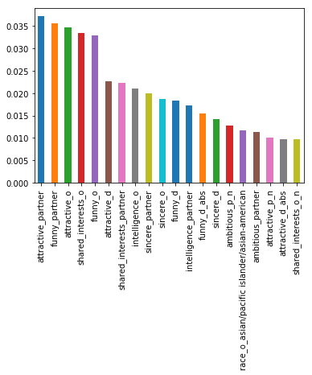

```python
feature_importance[:20].plot.bar()
```

**Prediction on training dataset**

```python
status, artifact = ds.run_model(dataset_train, model, model_type = 'DeepNeuralNetwork')
sleep(1)
ds.wait_for_job(artifact['job_name'])

status, prediction = ds.download_artifact(artifact['artifact_name'])
print("\n", prediction.head())
```

```
{'status': 'Running', 'starttime': '2019-04-17T21:13:10.118609', 'endtime': None, 'percent_complete': 0, 'job_type': 'RunModel', 'loss': 0.26659178733825684, 'generations': 7, 'dataset_names': ['Speed_Dating_Clean_SMOTE_train.csv'], 'artifact_names': ['4c4c97c9a88f4057b3b8a4692db34b23'], 'model_name…
{'status': 'Complete', 'starttime': '2019-04-17T21:13:10.118609', 'endtime': '2019-04-17T21:13:14.191163', 'percent_complete': 100, 'job_type': 'RunModel', 'loss': 0.26659178733825684, 'generations': 7, 'dataset_names': ['Speed_Dating_Clean_SMOTE_train.csv'], 'artifact_names': ['4c4c97c9a88f4057b3b8…

    match    prob_0        prob_1
0      1  0.000039  9.999610e-01
1      1  0.000024  9.999759e-01
2      0  1.000000  5.700000e-09
3      1  0.023619  9.763811e-01
4      0  0.999951  4.855150e-05
```

**Create plots comparing predictions with actual target**

```python
plt.plot(data_SMOTE_train[target], prediction[target], '.')
plt.plot([0,2.3e7],[0,2.3e7],'--k')
print('R^2 : ', r2_score(data_SMOTE_train[target], prediction[target]))
```

```
R^2 :  0.9352256100540515
```

```
               precision    recall  f1-score   support

           0       0.99      0.98      0.98      5494
           1       0.98      0.99      0.98      5498

   micro avg       0.98      0.98      0.98     10992
   macro avg       0.98      0.98      0.98     10992
weighted avg       0.98      0.98      0.98     10992
```

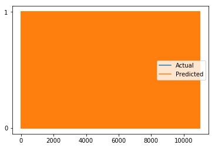

```python
unq = prediction[target].unique()[::-1]
p = np.zeros((len(prediction),))
a = np.zeros((len(prediction),))
for i,q in enumerate(unq):
    p += i*(prediction[target] == q).values
    a += i*(data_SMOTE_train[target] == q).values
#Plot predictions vs actual
plt.plot(a)
plt.plot(p)
plt.legend(['Actual','Predicted'])
plt.yticks([i for i in range(len(unq))],[q for q in unq]);
print("\n", classification_report(data_SMOTE_train[target], prediction[target]))
```

**Prediction on testing data**

```python
status, artifact = ds.run_model(dataset_test, model, model_type = 'DeepNeuralNetwork')
sleep(1)
ds.wait_for_job(artifact['job_name'])

status, prediction = ds.download_artifact(artifact['artifact_name'])
print("\n", prediction.head())
```

```
{'status': 'Running', 'starttime': '2019-04-17T21:13:34.605201', 'endtime': None, 'percent_complete': 0, 'job_type': 'RunModel', 'loss': 0.26659178733825684, 'generations': 7, 'dataset_names': ['Speed_Dating_Clean_SMOTE_test.csv'], 'artifact_names': ['8513ef8dc062495892fe8c9bc390dbb4'], 'model_name'…
{'status': 'Complete', 'starttime': '2019-04-17T21:13:34.605201', 'endtime': '2019-04-17T21:13:36.706048', 'percent_complete': 100, 'job_type': 'RunModel', 'loss': 0.26659178733825684, 'generations': 7, 'dataset_names': ['Speed_Dating_Clean_SMOTE_test.csv'], 'artifact_names': ['8513ef8dc062495892fe8…

    match    prob_0    prob_1
0      0  0.999968  0.000032
1      0  0.965936  0.034064
2      1  0.010906  0.989094
3      1  0.277957  0.722043
4      0  0.618885  0.381115
```

**Create plots comparing predictions with actual target**

```python
plt.plot(data_SMOTE_test[target], prediction[target], '.')
plt.plot([0,2.3e7],[0,2.3e7],'--k')
print('R^2 : ', r2_score(data_SMOTE_test[target], prediction[target]))
```

```
R^2 :  -0.3828268018170724
```

```
               precision    recall  f1-score   support

           0       0.62      0.81      0.70      1376
           1       0.73      0.49      0.59      1372

   micro avg       0.65      0.65      0.65      2748
   macro avg       0.67      0.65      0.65      2748
weighted avg       0.67      0.65      0.65      2748
```

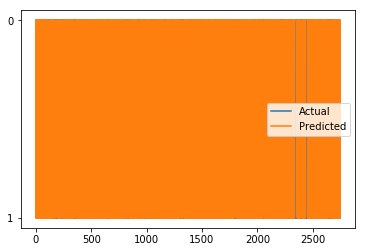

```python
unq = prediction[target].unique()[::-1]
p = np.zeros((len(prediction),))
a = np.zeros((len(prediction),))
for i,q in enumerate(unq):
    p += i*(prediction[target] == q).values
    a += i*(data_SMOTE_test[target] == q).values
#Plot predictions vs actual
plt.plot(a)
plt.plot(p)
plt.legend(['Actual','Predicted'])
plt.yticks([i for i in range(len(unq))],[q for q in unq]);
print("\n", classification_report(data_SMOTE_test[target], prediction[target]))
```

# RandomForest

**Analyze RandomForest model**

```python
# Analyze Darwin RandomForest model
status, artifact = ds.analyze_model(model, model_type = 'RandomForest')
sleep(1)
if status:
    ds.wait_for_job(artifact['job_name'])
else:
    print(artifact)
status, feature_importance = ds.download_artifact(artifact['artifact_name'])
```

```
{'status': 'Running', 'starttime': '2019-04-17T21:13:54.044538', 'endtime': None, 'percent_complete': 0, 'job_type': 'AnalyzeModel', 'loss': 0.26659178733825684, 'generations': 7, 'dataset_names': None, 'artifact_names': ['3bf4789bb8df4f058a192d2c8183b18b'], 'model_name': 'match_model20190418095459'…
{'status': 'Complete', 'starttime': '2019-04-17T21:13:54.044538', 'endtime': '2019-04-17T21:14:02.237153', 'percent_complete': 100, 'job_type': 'AnalyzeModel', 'loss': 0.26659178733825684, 'generations': 7, 'dataset_names': None, 'artifact_names': ['3bf4789bb8df4f058a192d2c8183b18b'], 'model_name': …
```

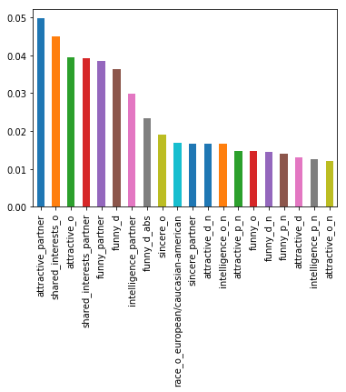

```python
feature_importance[:20].plot.bar()
```

**Prediction on training dataset**

```python
status, artifact = ds.run_model(dataset_train, model, model_type = 'RandomForest')
sleep(1)
ds.wait_for_job(artifact['job_name'])

status, prediction = ds.download_artifact(artifact['artifact_name'])
print("\n", prediction.head())
```

```
{'status': 'Running', 'starttime': '2019-04-17T21:14:11.987088', 'endtime': None, 'percent_complete': 0, 'job_type': 'RunModel', 'loss': 0.26659178733825684, 'generations': 7, 'dataset_names': ['Speed_Dating_Clean_SMOTE_train.csv'], 'artifact_names': ['da0bff03f0174b8cb60132bf4e0865b6'], 'model_name…
{'status': 'Complete', 'starttime': '2019-04-17T21:14:11.987088', 'endtime': '2019-04-17T21:14:19.389588', 'percent_complete': 100, 'job_type': 'RunModel', 'loss': 0.26659178733825684, 'generations': 7, 'dataset_names': ['Speed_Dating_Clean_SMOTE_train.csv'], 'artifact_names': ['da0bff03f0174b8cb601…

    match    prob_0    prob_1
0      1  0.034226  0.965774
1      1  0.113002  0.886998
2      1  0.486937  0.513063
3      0  0.629279  0.370721
4      1  0.468672  0.531328
```

**Create plots comparing predictions with actual target**

```python
plt.plot(data_SMOTE_train[target], prediction[target], '.')
plt.plot([0,2.3e7],[0,2.3e7],'--k')
print('R^2 : ', r2_score(data_SMOTE_train[target], prediction[target]))
```

```
R^2 :  0.7576418893033613
```

```
               precision    recall  f1-score   support

           0       0.94      0.93      0.94      5494
           1       0.93      0.95      0.94      5498

   micro avg       0.94      0.94      0.94     10992
   macro avg       0.94      0.94      0.94     10992
weighted avg       0.94      0.94      0.94     10992
```

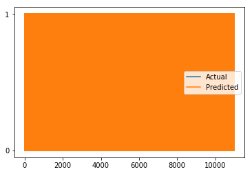

```python
unq = prediction[target].unique()[::-1]
p = np.zeros((len(prediction),))
a = np.zeros((len(prediction),))
for i,q in enumerate(unq):
    p += i*(prediction[target] == q).values
    a += i*(data_SMOTE_train[target] == q).values
#Plot predictions vs actual
plt.plot(a)
plt.plot(p)
plt.legend(['Actual','Predicted'])
plt.yticks([i for i in range(len(unq))],[q for q in unq]);
print("\n", classification_report(data_SMOTE_train[target], prediction[target]))
```

**Prediction on testing data**

```python
status, artifact = ds.run_model(dataset_test, model, model_type = 'RandomForest')
sleep(1)
ds.wait_for_job(artifact['job_name'])

status, prediction = ds.download_artifact(artifact['artifact_name'])
print("\n", prediction.head())
```

```
{'status': 'Running', 'starttime': '2019-04-17T21:14:32.471298', 'endtime': None, 'percent_complete': 0, 'job_type': 'RunModel', 'loss': 0.26659178733825684, 'generations': 7, 'dataset_names': ['Speed_Dating_Clean_SMOTE_test.csv'], 'artifact_names': ['ff4fbe2dc33f46d2ab31345db40371e4'], 'model_name'…
{'status': 'Complete', 'starttime': '2019-04-17T21:14:32.471298', 'endtime': '2019-04-17T21:14:37.385615', 'percent_complete': 100, 'job_type': 'RunModel', 'loss': 0.26659178733825684, 'generations': 7, 'dataset_names': ['Speed_Dating_Clean_SMOTE_test.csv'], 'artifact_names': ['ff4fbe2dc33f46d2ab313…

    match    prob_0    prob_1
0      0  0.906414  0.093586
1      1  0.037260  0.962740
2      1  0.135072  0.864928
3      1  0.072659  0.927341
4      0  0.751214  0.248786
```

**Create plots comparing predictions with actual target**

```python
plt.plot(data_SMOTE_test[target], prediction[target], '.')
plt.plot([0,2.3e7],[0,2.3e7],'--k')
print('R^2 : ', r2_score(data_SMOTE_test[target], prediction[target]))
```

```
R^2 :  -0.15284087056749618
```

```
               precision    recall  f1-score   support

           0       0.83      0.53      0.65      1376
           1       0.66      0.89      0.76      1372

   micro avg       0.71      0.71      0.71      2748
   macro avg       0.74      0.71      0.70      2748
weighted avg       0.74      0.71      0.70      2748
```

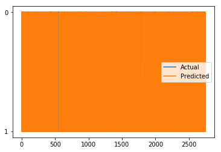

```python
unq = prediction[target].unique()[::-1]
p = np.zeros((len(prediction),))
a = np.zeros((len(prediction),))
for i,q in enumerate(unq):
    p += i*(prediction[target] == q).values
    a += i*(data_SMOTE_test[target] == q).values
#Plot predictions vs actual
plt.plot(a)
plt.plot(p)
plt.legend(['Actual','Predicted'])
plt.yticks([i for i in range(len(unq))],[q for q in unq]);
print("\n", classification_report(data_SMOTE_test[target], prediction[target]))
```

# GradientBoosted

**Analyze GradientBoosted model**

```python
# Analyze Darwin GradientBoosted model
status, artifact = ds.analyze_model(model, model_type = 'GradientBoosted')
sleep(1)
if status:
    ds.wait_for_job(artifact['job_name'])
else:
    print(artifact)
status, feature_importance = ds.download_artifact(artifact['artifact_name'])
```

```
{'status': 'Running', 'starttime': '2019-04-17T21:14:51.063432', 'endtime': None, 'percent_complete': 0, 'job_type': 'AnalyzeModel', 'loss': 0.26659178733825684, 'generations': 7, 'dataset_names': None, 'artifact_names': ['d815dea8a8044d98ba9e396414b9a5f4'], 'model_name': 'match_model20190418095459'…
{'status': 'Complete', 'starttime': '2019-04-17T21:14:51.063432', 'endtime': '2019-04-17T21:14:55.142422', 'percent_complete': 100, 'job_type': 'AnalyzeModel', 'loss': 0.26659178733825684, 'generations': 7, 'dataset_names': None, 'artifact_names': ['d815dea8a8044d98ba9e396414b9a5f4'], 'model_name': …
```

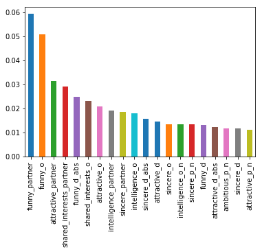

```python
feature_importance[:20].plot.bar()
```

**Prediction on training dataset**

```python
status, artifact = ds.run_model(dataset_train, model, model_type = 'GradientBoosted')
sleep(1)
ds.wait_for_job(artifact['job_name'])

status, prediction = ds.download_artifact(artifact['artifact_name'])
print("\n", prediction.head())
```

```
{'status': 'Running', 'starttime': '2019-04-17T21:15:09.106877', 'endtime': None, 'percent_complete': 0, 'job_type': 'RunModel', 'loss': 0.26659178733825684, 'generations': 7, 'dataset_names': ['Speed_Dating_Clean_SMOTE_train.csv'], 'artifact_names': ['aada2d3858b349599f55bcecf4270694'], 'model_name…
{'status': 'Complete', 'starttime': '2019-04-17T21:15:09.106877', 'endtime': '2019-04-17T21:15:12.731149', 'percent_complete': 100, 'job_type': 'RunModel', 'loss': 0.26659178733825684, 'generations': 7, 'dataset_names': ['Speed_Dating_Clean_SMOTE_train.csv'], 'artifact_names': ['aada2d3858b349599f55…

    match    prob_0    prob_1
0      1  0.003799  0.996201
1      1  0.000550  0.999450
2      0  0.954083  0.045917
3      1  0.288209  0.711791
4      0  0.968108  0.031892
```

**Create plots comparing predictions with actual target**

```python
plt.plot(data_SMOTE_train[target], prediction[target], '.')
plt.plot([0,2.3e7],[0,2.3e7],'--k')
print('R^2 : ', r2_score(data_SMOTE_train[target], prediction[target]))
```

```
R^2 :  0.9348617089869394
```

```
               precision    recall  f1-score   support

           0       0.98      0.99      0.98      5494
           1       0.99      0.98      0.98      5498

   micro avg       0.98      0.98      0.98     10992
   macro avg       0.98      0.98      0.98     10992
weighted avg       0.98      0.98      0.98     10992
```

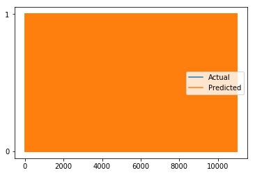

```python
unq = prediction[target].unique()[::-1]
p = np.zeros((len(prediction),))
a = np.zeros((len(prediction),))
for i,q in enumerate(unq):
    p += i*(prediction[target] == q).values
    a += i*(data_SMOTE_train[target] == q).values
#Plot predictions vs actual
plt.plot(a)
plt.plot(p)
plt.legend(['Actual','Predicted'])
plt.yticks([i for i in range(len(unq))],[q for q in unq]);
print("\n", classification_report(data_SMOTE_train[target], prediction[target]))
```

**Prediction on testing data**

```python
status, artifact = ds.run_model(dataset_test, model, model_type = 'GradientBoosted')
sleep(1)
ds.wait_for_job(artifact['job_name'])

status, prediction = ds.download_artifact(artifact['artifact_name'])
print("\n", prediction.head())
```

```
{'status': 'Running', 'starttime': '2019-04-17T21:15:30.063836', 'endtime': None, 'percent_complete': 0, 'job_type': 'RunModel', 'loss': 0.26659178733825684, 'generations': 7, 'dataset_names': ['Speed_Dating_Clean_SMOTE_test.csv'], 'artifact_names': ['1ac01bd4d4fe42bd8e4e64ed3b8558ff'], 'model_name'…
{'status': 'Complete', 'starttime': '2019-04-17T21:15:30.063836', 'endtime': '2019-04-17T21:15:32.27206', 'percent_complete': 100, 'job_type': 'RunModel', 'loss': 0.26659178733825684, 'generations': 7, 'dataset_names': ['Speed_Dating_Clean_SMOTE_test.csv'], 'artifact_names': ['1ac01bd4d4fe42bd8e4e64…

    match    prob_0    prob_1
0      0  0.966293  0.033707
1      1  0.004012  0.995988
2      1  0.003811  0.996189
3      1  0.000095  0.999905
4      0  0.902267  0.097733
```

**Create plots comparing predictions with actual target**

```python
plt.plot(data_SMOTE_test[target], prediction[target], '.')
plt.plot([0,2.3e7],[0,2.3e7],'--k')
print('R^2 : ', r2_score(data_SMOTE_test[target], prediction[target]))
```

```
R^2 :  -0.35080344430130883
```

```
               precision    recall  f1-score   support

           0       0.97      0.34      0.50      1376
           1       0.60      0.99      0.75      1372

   micro avg       0.66      0.66      0.66      2748
   macro avg       0.78      0.66      0.62      2748
weighted avg       0.78      0.66      0.62      2748
```

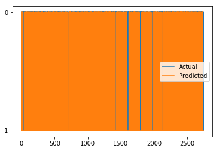

```python
unq = prediction[target].unique()[::-1]
p = np.zeros((len(prediction),))
a = np.zeros((len(prediction),))
for i,q in enumerate(unq):
    p += i*(prediction[target] == q).values
    a += i*(data_SMOTE_test[target] == q).values
#Plot predictions vs actual
plt.plot(a)
plt.plot(p)
plt.legend(['Actual','Predicted'])
plt.yticks([i for i in range(len(unq))],[q for q in unq]);
print("\n", classification_report(data_SMOTE_test[target], prediction[target]))
```

# Darwin (noSMOTE) : imbalanced data

```python
ds = DarwinSdk()
ds.set_url('https://amb-demo-api.sparkcognition.com/v1/')
status, msg = ds.auth_login_user('EMMIECHNG@UTEXAS.EDU', 'QMCZgepW6u')

if not status:
    print(msg)
```

```python
dataset_train = 'Speed_Dating_Clean_noSMOTE_train.csv'
dataset_test = 'Speed_Dating_Clean_noSMOTE_test.csv'
```

**Upload datasets**

```python
# Upload train dataset to Darwin
data_noSMOTE_train = pd.read_csv("Speed_Dating_Clean_noSMOTE_train.csv")
status, dataset = ds.upload_dataset("Speed_Dating_Clean_noSMOTE_train.csv")

if not status:
    print(dataset)
```

```python
# Upload test dataset to Darwin
data_noSMOTE_test = pd.read_csv("Speed_Dating_Clean_noSMOTE_test.csv")
status, dataset = ds.upload_dataset("Speed_Dating_Clean_noSMOTE_test.csv")

if not status:
    print(dataset)
```

```python
ds.lookup_dataset()
```

```
(True,
 [{'name': 'Speed_Dating_Clean_noSMOTE_test.csv',
   'mbytes': 3.3188085556030273,
   'minimum_recommeded_train_time': '5 minutes',
   'updated_at': '2019-04-17T21:35:42.116378',
   'categorical': None,
   'sequential': None,
   'imbalanced': None},
  {'name': 'Speed_Dating_Clean_noSMOTE_train.csv',
   'mbytes': 13.221643447875977,
   'minimum_recommeded_train_time': '5 minutes',
   'updated_at': '2019-04-17T21:35:26.778258',
   'categorical': None,
   'sequential': None,
   'imbalanced': None}])
```

**Clean datasets**

```python
# Clean train dataset on Darwin
target = "match"
status, job_id = ds.clean_data(dataset_train, target = target)

if status:
    ds.wait_for_job(job_id['job_name'])
else:
    print(job_id)
```

```
{'status': 'Requested', 'starttime': '2019-04-17T21:35:43.466304', 'endtime': None, 'percent_complete': 0, 'job_type': 'CleanDataTiny', 'loss': None, 'generations': None, 'dataset_names': ['Speed_Dating_Clean_noSMOTE_train.csv'], 'artifact_names': ['36f0a014dd6c489b8baaa974ef9edf03'], 'model_name': …
{'status': 'Running', 'starttime': '2019-04-17T21:35:43.466304', 'endtime': None, 'percent_complete': 0, 'job_type': 'CleanDataTiny', 'loss': None, 'generations': None, 'dataset_names': ['Speed_Dating_Clean_noSMOTE_train.csv'], 'artifact_names': ['36f0a014dd6c489b8baaa974ef9edf03'], 'model_name': No…
{'status': 'Running', 'starttime': '2019-04-17T21:35:43.466304', 'endtime': None, 'percent_complete': 0, 'job_type': 'CleanDataTiny', 'loss': None, 'generations': None, 'dataset_names': ['Speed_Dating_Clean_noSMOTE_train.csv'], 'artifact_names': ['36f0a014dd6c489b8baaa974ef9edf03'], 'model_name': No…
{'status': 'Complete', 'starttime': '2019-04-17T21:35:43.466304', 'endtime': '2019-04-17T21:36:15.047409', 'percent_complete': 100, 'job_type': 'CleanDataTiny', 'loss': None, 'generations': None, 'dataset_names': ['Speed_Dating_Clean_noSMOTE_train.csv'], 'artifact_names': ['36f0a014dd6c489b8baaa974e…
```

```python
# Clean test dataset on Darwin
target = "match"
status, job_id = ds.clean_data(dataset_test, target = target)

if status:
    ds.wait_for_job(job_id['job_name'])
else:
    print(job_id)
```

```
{'status': 'Requested', 'starttime': '2019-04-17T21:36:29.984397', 'endtime': None, 'percent_complete': 0, 'job_type': 'CleanDataTiny', 'loss': None, 'generations': None, 'dataset_names': ['Speed_Dating_Clean_noSMOTE_test.csv'], 'artifact_names': ['10b846dbfa1a41c8a65d149f109b5b8d'], 'model_name': N…
{'status': 'Running', 'starttime': '2019-04-17T21:36:29.984397', 'endtime': None, 'percent_complete': 0, 'job_type': 'CleanDataTiny', 'loss': None, 'generations': None, 'dataset_names': ['Speed_Dating_Clean_noSMOTE_test.csv'], 'artifact_names': ['10b846dbfa1a41c8a65d149f109b5b8d'], 'model_name': Non…
{'status': 'Complete', 'starttime': '2019-04-17T21:36:29.984397', 'endtime': '2019-04-17T21:36:50.66826', 'percent_complete': 100, 'job_type': 'CleanDataTiny', 'loss': None, 'generations': None, 'dataset_names': ['Speed_Dating_Clean_noSMOTE_test.csv'], 'artifact_names': ['10b846dbfa1a41c8a65d149f109…
```

**Create model**

```python
# Create Darwin model
model = target + "_model_noSMOTE" + ts
status, job_id = ds.create_model(dataset_names = dataset_train,
                                 model_name = model,
                                 max_train_time = '00:05')

if status:
    ds.wait_for_job(job_id['job_name'])
else:
    print(job_id)
```

[output not shown]

[output cut: 8 more lines]

```python
# Extra training for Darwin model
status, job_id = ds.resume_training_model(dataset_names = dataset_train,
                                         model_name = model,
                                         max_train_time = '00:05')

if status:
    ds.wait_for_job(job_id['job_name'])
else:
    print(job_id)
```

[output not shown]

[output cut: 8 more lines]

# Best model decided by Darwin

**Analyze model**

```python
# Analyze Darwin model
status, artifact = ds.analyze_model(model)
sleep(1)
if status:
    ds.wait_for_job(artifact['job_name'])
else:
    print(artifact)
status, feature_importance = ds.download_artifact(artifact['artifact_name'])
```

```
{'status': 'Running', 'starttime': '2019-04-17T21:48:10.372526', 'endtime': None, 'percent_complete': 0, 'job_type': 'AnalyzeModel', 'loss': 0.45836010575294495, 'generations': 10, 'dataset_names': None, 'artifact_names': ['94539d116b69455abda5304ec2f1bd72'], 'model_name': 'match_model_noSMOTE201904…
{'status': 'Complete', 'starttime': '2019-04-17T21:48:10.372526', 'endtime': '2019-04-17T21:48:12.823937', 'percent_complete': 100, 'job_type': 'AnalyzeModel', 'loss': 0.45836010575294495, 'generations': 10, 'dataset_names': None, 'artifact_names': ['94539d116b69455abda5304ec2f1bd72'], 'model_name':…
```

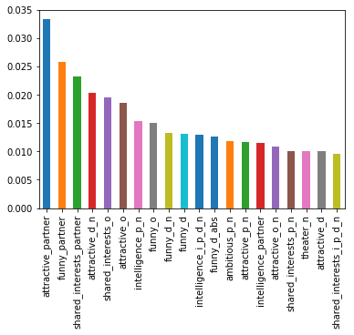

```python
feature_importance[:20].plot.bar()
```

**Prediction on training dataset**

```python
status, artifact = ds.run_model(dataset_train, model)
sleep(1)
ds.wait_for_job(artifact['job_name'])

status, prediction = ds.download_artifact(artifact['artifact_name'])
print("\n", prediction.head())
```

```
{'status': 'Running', 'starttime': '2019-04-17T21:48:28.572363', 'endtime': None, 'percent_complete': 0, 'job_type': 'RunModel', 'loss': 0.45836010575294495, 'generations': 10, 'dataset_names': ['Speed_Dating_Clean_noSMOTE_train.csv'], 'artifact_names': ['8cb27a5068fb4459887e555cad65d35d'], 'model_n…
{'status': 'Complete', 'starttime': '2019-04-17T21:48:28.572363', 'endtime': '2019-04-17T21:48:30.59763', 'percent_complete': 100, 'job_type': 'RunModel', 'loss': 0.45836010575294495, 'generations': 10, 'dataset_names': ['Speed_Dating_Clean_noSMOTE_train.csv'], 'artifact_names': ['8cb27a5068fb445988…

    match    prob_0    prob_1
0      0  0.941848  0.058152
1      0  0.995293  0.004707
2      0  0.983115  0.016885
3      0  0.978530  0.021470
4      0  0.971369  0.028631
```

**Create plots comparing predictions with actual target**

```python
plt.plot(data_noSMOTE_train[target], prediction[target], '.')
plt.plot([0,2.3e7],[0,2.3e7],'--k')
print('R^2 : ', r2_score(data_noSMOTE_train[target], prediction[target]))
```

```
R^2 :  0.17810764210962815
```

```
               precision    recall  f1-score   support

           0       0.90      0.98      0.94      5512
           1       0.79      0.43      0.55      1064

   micro avg       0.89      0.89      0.89      6576
   macro avg       0.84      0.70      0.74      6576
weighted avg       0.88      0.89      0.87      6576
```

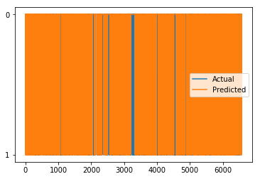

```python
unq = prediction[target].unique()[::-1]
p = np.zeros((len(prediction),))
a = np.zeros((len(prediction),))
for i,q in enumerate(unq):
    p += i*(prediction[target] == q).values
    a += i*(data_noSMOTE_train[target] == q).values
#Plot predictions vs actual
plt.plot(a)
plt.plot(p)
plt.legend(['Actual','Predicted'])
plt.yticks([i for i in range(len(unq))],[q for q in unq]);
print("\n", classification_report(data_noSMOTE_train[target], prediction[target]))
```

**Prediction on testing data**

```python
status, artifact = ds.run_model(dataset_test, model)
sleep(1)
ds.wait_for_job(artifact['job_name'])

status, prediction = ds.download_artifact(artifact['artifact_name'])
print("\n", prediction.head())
```

```
{'status': 'Running', 'starttime': '2019-04-17T21:48:47.365974', 'endtime': None, 'percent_complete': 0, 'job_type': 'RunModel', 'loss': 0.45836010575294495, 'generations': 10, 'dataset_names': ['Speed_Dating_Clean_noSMOTE_test.csv'], 'artifact_names': ['fb1d0595e02d4454ab6c6e60ba18bb03'], 'model_na…
{'status': 'Failed', 'starttime': '2019-04-17T21:48:47.365974', 'endtime': '2019-04-17T21:48:48.993176', 'percent_complete': 100, 'job_type': 'RunModel', 'loss': 0.45836010575294495, 'generations': 10, 'dataset_names': ['Speed_Dating_Clean_noSMOTE_test.csv'], 'artifact_names': ['fb1d0595e02d4454ab6c…
```

[output not shown]

**Create plots comparing predictions with actual target**

```python
plt.plot(data_noSMOTE_test[target], prediction[target], '.')
plt.plot([0,2.3e7],[0,2.3e7],'--k')
print('R^2 : ', r2_score(data_noSMOTE_test[target], prediction[target]))
```

```python
unq = prediction[target].unique()[::-1]
p = np.zeros((len(prediction),))
a = np.zeros((len(prediction),))
for i,q in enumerate(unq):
    p += i*(prediction[target] == q).values
    a += i*(data_noSMOTE_test[target] == q).values
#Plot predictions vs actual
plt.plot(a)
plt.plot(p)
plt.legend(['Actual','Predicted'])
plt.yticks([i for i in range(len(unq))],[q for q in unq]);
print("\n", classification_report(data_noSMOTE_test[target], prediction[target]))
```

**Model Darwin used**

```python
status, model_type = ds.lookup_model_name(model)
print(model_type)
```

```
{'type': 'Supervised', 'updated_at': '2019-04-17T21:48:05.171406', 'trained_on': ['Speed_Dating_Clean_noSMOTE_train.csv'], 'loss': 0.45836010575294495, 'generations': 10, 'parameters': {'train_time': '00:05', 'target': 'match', 'recurrent': False, 'max_unique_values': 50, 'max_int_uniques': 15, 'imp…
```

```python
ds.display_population(model)
```

```
(True,
 {'population': {'model_types': {'DeepNeuralNetwork': {'model_description': [{'layer 1': {'type': 'LinearGene',
        'parameters': {'activation': 'relu', 'numunits': 562}}},
      {'layer 2': {'type': 'LinearGene',
        'parameters': {'activation': 'relu', 'numunits': 2}}}],
     'loss_function': 'CrossEntropy',
     'fitness': -inf},
    'RandomForest': {'model_description': {'type': 'RandomForestClassifier',
      'parameters': {'bootstrap': False,
       'criterion': 'gini',
       'max_depth': 9,
       'max_features': 0.8437777253482013,
       'max_leaf_nodes': None,
       'min_impurity_decrease': 0.0,
       'min_samples_leaf': 19,
       'min_samples_split': 5,
       'n_jobs': -1,
       'min_weight_fraction_leaf': 0.0,
       'n_estimators': 335}},
     'loss_function': 'CrossEntropy',
     'fitness': 1.8311069252255394},
    'GradientBoosted': {'model_description': {'type': 'XGBClassifier',
      'parameters': {'base_score': 0.5,
       'colsample_bylevel': 1,
       'colsample_bytree': 1,
       'gamma': 0,
       'learning_rate': 0.3147300819471908,
       'max_delta_step': 0,
       'max_depth': 1,
       'min_child_weight': 12,
       'n_estimators': 288,
       'n_jobs': -1,
       'reg_alpha': 0,
       'reg_lambda': 1,
       'scale_pos_weight': 1,
       'subsample': 0.9081972824987428}},
     'loss_function': 'CrossEntropy',
     'fitness': 1.8593328728452527}}}})
```

# DeepNeuralNetwork

**Analyze DeepNeuralNetwork model**

```python
# Analyze Darwin DeepNeuralNetwork model
status, artifact = ds.analyze_model(model, model_type = 'DeepNeuralNetwork')
sleep(1)
if status:
    ds.wait_for_job(artifact['job_name'])
else:
    print(artifact)
status, feature_importance = ds.download_artifact(artifact['artifact_name'])
```

```
{'status': 'Running', 'starttime': '2019-04-17T21:50:38.624852', 'endtime': None, 'percent_complete': 0, 'job_type': 'AnalyzeModel', 'loss': 0.45836010575294495, 'generations': 10, 'dataset_names': None, 'artifact_names': ['795d314365744745811abbb106571779'], 'model_name': 'match_model_noSMOTE201904…
{'status': 'Complete', 'starttime': '2019-04-17T21:50:38.624852', 'endtime': '2019-04-17T21:50:41.821165', 'percent_complete': 100, 'job_type': 'AnalyzeModel', 'loss': 0.45836010575294495, 'generations': 10, 'dataset_names': None, 'artifact_names': ['795d314365744745811abbb106571779'], 'model_name':…
```

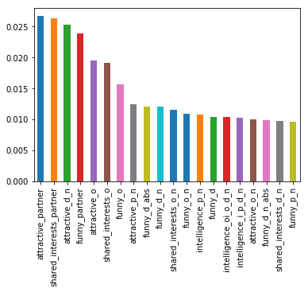

```python
feature_importance[:20].plot.bar()
```

**Prediction on training dataset**

```python
status, artifact = ds.run_model(dataset_train, model, model_type = 'DeepNeuralNetwork')
sleep(1)
ds.wait_for_job(artifact['job_name'])

status, prediction = ds.download_artifact(artifact['artifact_name'])
print("\n", prediction.head())
```

```
{'status': 'Running', 'starttime': '2019-04-17T21:50:57.414989', 'endtime': None, 'percent_complete': 0, 'job_type': 'RunModel', 'loss': 0.45836010575294495, 'generations': 10, 'dataset_names': ['Speed_Dating_Clean_noSMOTE_train.csv'], 'artifact_names': ['557dc20a0b514e73b7df19f94825ead7'], 'model_n…
{'status': 'Complete', 'starttime': '2019-04-17T21:50:57.414989', 'endtime': '2019-04-17T21:51:00.381464', 'percent_complete': 100, 'job_type': 'RunModel', 'loss': 0.45836010575294495, 'generations': 10, 'dataset_names': ['Speed_Dating_Clean_noSMOTE_train.csv'], 'artifact_names': ['557dc20a0b514e73b…

    match    prob_0    prob_1
0      0  0.949241  0.050759
1      0  0.998009  0.001991
2      0  0.987505  0.012495
3      0  0.982843  0.017158
4      0  0.968469  0.031531
```

**Create plots comparing predictions with actual target**

```python
plt.plot(data_noSMOTE_train[target], prediction[target], '.')
plt.plot([0,2.3e7],[0,2.3e7],'--k')
print('R^2 : ', r2_score(data_noSMOTE_train[target], prediction[target]))
```

```
R^2 :  0.35975370210722746
```

```
               precision    recall  f1-score   support

           0       0.92      0.98      0.95      5512
           1       0.85      0.56      0.68      1064

   micro avg       0.91      0.91      0.91      6576
   macro avg       0.89      0.77      0.81      6576
weighted avg       0.91      0.91      0.91      6576
```

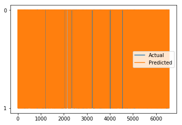

```python
unq = prediction[target].unique()[::-1]
p = np.zeros((len(prediction),))
a = np.zeros((len(prediction),))
for i,q in enumerate(unq):
    p += i*(prediction[target] == q).values
    a += i*(data_noSMOTE_train[target] == q).values
#Plot predictions vs actual
plt.plot(a)
plt.plot(p)
plt.legend(['Actual','Predicted'])
plt.yticks([i for i in range(len(unq))],[q for q in unq]);
print("\n", classification_report(data_noSMOTE_train[target], prediction[target]))
```

**Prediction on testing data**

```python
status, artifact = ds.run_model(dataset_test, model, model_type = 'DeepNeuralNetwork')
sleep(1)
ds.wait_for_job(artifact['job_name'])

status, prediction = ds.download_artifact(artifact['artifact_name'])
print("\n", prediction.head())
```

```
{'status': 'Running', 'starttime': '2019-04-17T21:51:19.759982', 'endtime': None, 'percent_complete': 0, 'job_type': 'RunModel', 'loss': 0.45836010575294495, 'generations': 10, 'dataset_names': ['Speed_Dating_Clean_noSMOTE_test.csv'], 'artifact_names': ['c4f8a081de7d45958d9caaed2a5b7040'], 'model_na…
{'status': 'Failed', 'starttime': '2019-04-17T21:51:19.759982', 'endtime': '2019-04-17T21:51:21.449559', 'percent_complete': 100, 'job_type': 'RunModel', 'loss': 0.45836010575294495, 'generations': 10, 'dataset_names': ['Speed_Dating_Clean_noSMOTE_test.csv'], 'artifact_names': ['c4f8a081de7d45958d9c…
```

[output not shown]

**Create plots comparing predictions with actual target**

```python
plt.plot(data_noSMOTE_test[target], prediction[target], '.')
plt.plot([0,2.3e7],[0,2.3e7],'--k')
print('R^2 : ', r2_score(data_noSMOTE_test[target], prediction[target]))
```

```python
unq = prediction[target].unique()[::-1]
p = np.zeros((len(prediction),))
a = np.zeros((len(prediction),))
for i,q in enumerate(unq):
    p += i*(prediction[target] == q).values
    a += i*(data_noSMOTE_test[target] == q).values
#Plot predictions vs actual
plt.plot(a)
plt.plot(p)
plt.legend(['Actual','Predicted'])
plt.yticks([i for i in range(len(unq))],[q for q in unq]);
print("\n", classification_report(data_noSMOTE_test[target], prediction[target]))
```

# RandomForest

**Analyze RandomForest model**

```python
# Analyze Darwin RandomForest model
status, artifact = ds.analyze_model(model, model_type = 'RandomForest')
sleep(1)
if status:
    ds.wait_for_job(artifact['job_name'])
else:
    print(artifact)
status, feature_importance = ds.download_artifact(artifact['artifact_name'])
```

```
{'status': 'Running', 'starttime': '2019-04-17T21:52:15.560507', 'endtime': None, 'percent_complete': 0, 'job_type': 'AnalyzeModel', 'loss': 0.45836010575294495, 'generations': 10, 'dataset_names': None, 'artifact_names': ['4b8491a5ce0b489982b867a432bb515b'], 'model_name': 'match_model_noSMOTE201904…
{'status': 'Complete', 'starttime': '2019-04-17T21:52:15.560507', 'endtime': '2019-04-17T21:52:19.709502', 'percent_complete': 100, 'job_type': 'AnalyzeModel', 'loss': 0.45836010575294495, 'generations': 10, 'dataset_names': None, 'artifact_names': ['4b8491a5ce0b489982b867a432bb515b'], 'model_name':…
```

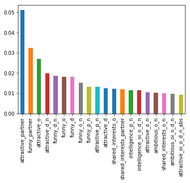

```python
feature_importance[:20].plot.bar()
```

**Prediction on training dataset**

```python
status, artifact = ds.run_model(dataset_train, model, model_type = 'RandomForest')
sleep(1)
ds.wait_for_job(artifact['job_name'])

status, prediction = ds.download_artifact(artifact['artifact_name'])
print("\n", prediction.head())
```

```
{'status': 'Running', 'starttime': '2019-04-17T21:52:33.562225', 'endtime': None, 'percent_complete': 0, 'job_type': 'RunModel', 'loss': 0.45836010575294495, 'generations': 10, 'dataset_names': ['Speed_Dating_Clean_noSMOTE_train.csv'], 'artifact_names': ['45a0cc2f667642e6a0c05032201b3e8b'], 'model_n…
{'status': 'Complete', 'starttime': '2019-04-17T21:52:33.562225', 'endtime': '2019-04-17T21:52:37.178462', 'percent_complete': 100, 'job_type': 'RunModel', 'loss': 0.45836010575294495, 'generations': 10, 'dataset_names': ['Speed_Dating_Clean_noSMOTE_train.csv'], 'artifact_names': ['45a0cc2f667642e6a…

    match    prob_0    prob_1
0      0  0.962473  0.037527
1      0  0.992716  0.007284
2      0  0.944645  0.055355
3      0  0.976857  0.023143
4      0  0.976671  0.023330
```

**Create plots comparing predictions with actual target**

```python
plt.plot(data_noSMOTE_train[target], prediction[target], '.')
plt.plot([0,2.3e7],[0,2.3e7],'--k')
print('R^2 : ', r2_score(data_noSMOTE_train[target], prediction[target]))
```

```
R^2 :  0.31041773519429927
```

```
               precision    recall  f1-score   support

           0       0.91      0.98      0.95      5512
           1       0.86      0.50      0.64      1064

   micro avg       0.91      0.91      0.91      6576
   macro avg       0.89      0.74      0.79      6576
weighted avg       0.90      0.91      0.90      6576
```

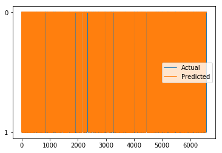

```python
unq = prediction[target].unique()[::-1]
p = np.zeros((len(prediction),))
a = np.zeros((len(prediction),))
for i,q in enumerate(unq):
    p += i*(prediction[target] == q).values
    a += i*(data_noSMOTE_train[target] == q).values
#Plot predictions vs actual
plt.plot(a)
plt.plot(p)
plt.legend(['Actual','Predicted'])
plt.yticks([i for i in range(len(unq))],[q for q in unq]);
print("\n", classification_report(data_noSMOTE_train[target], prediction[target]))
```

**Prediction on testing data**

```python
status, artifact = ds.run_model(dataset_test, model, model_type = 'RandomForest')
sleep(1)
ds.wait_for_job(artifact['job_name'])

status, prediction = ds.download_artifact(artifact['artifact_name'])
print("\n", prediction.head())
```

```
{'status': 'Running', 'starttime': '2019-04-17T21:52:53.068971', 'endtime': None, 'percent_complete': 0, 'job_type': 'RunModel', 'loss': 0.45836010575294495, 'generations': 10, 'dataset_names': ['Speed_Dating_Clean_noSMOTE_test.csv'], 'artifact_names': ['2f008ea9a04d43dcad8ed757d7bd5d88'], 'model_na…
{'status': 'Failed', 'starttime': '2019-04-17T21:52:53.068971', 'endtime': '2019-04-17T21:52:54.492719', 'percent_complete': 100, 'job_type': 'RunModel', 'loss': 0.45836010575294495, 'generations': 10, 'dataset_names': ['Speed_Dating_Clean_noSMOTE_test.csv'], 'artifact_names': ['2f008ea9a04d43dcad8e…
```

[output not shown]

**Create plots comparing predictions with actual target**

```python
plt.plot(data_noSMOTE_test[target], prediction[target], '.')
plt.plot([0,2.3e7],[0,2.3e7],'--k')
print('R^2 : ', r2_score(data_noSMOTE_test[target], prediction[target]))
```

```python
unq = prediction[target].unique()[::-1]
p = np.zeros((len(prediction),))
a = np.zeros((len(prediction),))
for i,q in enumerate(unq):
    p += i*(prediction[target] == q).values
    a += i*(data_noSMOTE_test[target] == q).values
#Plot predictions vs actual
plt.plot(a)
plt.plot(p)
plt.legend(['Actual','Predicted'])
plt.yticks([i for i in range(len(unq))],[q for q in unq]);
print("\n", classification_report(data_noSMOTE_test[target], prediction[target]))
```

# GradientBoosted

**Analyze GradientBoosted model**

```python
# Analyze Darwin GradientBoosted model
status, artifact = ds.analyze_model(model, model_type = 'GradientBoosted')
sleep(1)
if status:
    ds.wait_for_job(artifact['job_name'])
else:
    print(artifact)
status, feature_importance = ds.download_artifact(artifact['artifact_name'])
```

```
{'status': 'Running', 'starttime': '2019-04-17T21:53:46.717831', 'endtime': None, 'percent_complete': 0, 'job_type': 'AnalyzeModel', 'loss': 0.45836010575294495, 'generations': 10, 'dataset_names': None, 'artifact_names': ['0d8edcbedaf541f2871c69926c1cbb8c'], 'model_name': 'match_model_noSMOTE201904…
{'status': 'Complete', 'starttime': '2019-04-17T21:53:46.717831', 'endtime': '2019-04-17T21:53:48.993755', 'percent_complete': 100, 'job_type': 'AnalyzeModel', 'loss': 0.45836010575294495, 'generations': 10, 'dataset_names': None, 'artifact_names': ['0d8edcbedaf541f2871c69926c1cbb8c'], 'model_name':…
```

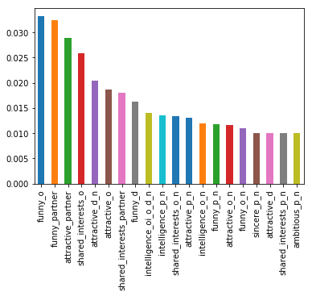

```python
feature_importance[:20].plot.bar()
```

**Prediction on training dataset**

```python
status, artifact = ds.run_model(dataset_train, model, model_type = 'GradientBoosted')
sleep(1)
ds.wait_for_job(artifact['job_name'])

status, prediction = ds.download_artifact(artifact['artifact_name'])
print("\n", prediction.head())
```

```
{'status': 'Running', 'starttime': '2019-04-17T21:54:04.74197', 'endtime': None, 'percent_complete': 0, 'job_type': 'RunModel', 'loss': 0.45836010575294495, 'generations': 10, 'dataset_names': ['Speed_Dating_Clean_noSMOTE_train.csv'], 'artifact_names': ['b29917055304481d8d2090eaa1bf6866'], 'model_na…
{'status': 'Complete', 'starttime': '2019-04-17T21:54:04.74197', 'endtime': '2019-04-17T21:54:07.124703', 'percent_complete': 100, 'job_type': 'RunModel', 'loss': 0.45836010575294495, 'generations': 10, 'dataset_names': ['Speed_Dating_Clean_noSMOTE_train.csv'], 'artifact_names': ['b29917055304481d8d…

    match    prob_0    prob_1
0      0  0.979476  0.020524
1      0  0.964540  0.035460
2      0  0.965663  0.034337
3      0  0.986914  0.013086
4      0  0.914186  0.085814
```

**Create plots comparing predictions with actual target**

```python
plt.plot(data_noSMOTE_train[target], prediction[target], '.')
plt.plot([0,2.3e7],[0,2.3e7],'--k')
print('R^2 : ', r2_score(data_noSMOTE_train[target], prediction[target]))
```

```
R^2 :  0.20165435359079842
```

```
               precision    recall  f1-score   support

           0       0.90      0.98      0.94      5512
           1       0.78      0.46      0.58      1064

   micro avg       0.89      0.89      0.89      6576
   macro avg       0.84      0.72      0.76      6576
weighted avg       0.88      0.89      0.88      6576
```

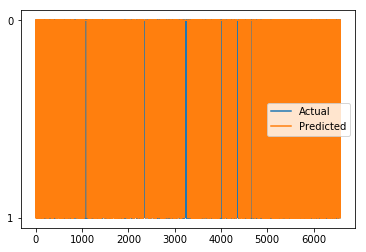

```python
unq = prediction[target].unique()[::-1]
p = np.zeros((len(prediction),))
a = np.zeros((len(prediction),))
for i,q in enumerate(unq):
    p += i*(prediction[target] == q).values
    a += i*(data_noSMOTE_train[target] == q).values
#Plot predictions vs actual
plt.plot(a)
plt.plot(p)
plt.legend(['Actual','Predicted'])
plt.yticks([i for i in range(len(unq))],[q for q in unq]);
print("\n", classification_report(data_noSMOTE_train[target], prediction[target]))
```

**Prediction on testing data**

```python
status, artifact = ds.run_model(dataset_test, model, model_type = 'GradientBoosted')
sleep(1)
ds.wait_for_job(artifact['job_name'])

status, prediction = ds.download_artifact(artifact['artifact_name'])
print("\n", prediction.head())
```

```
{'status': 'Failed', 'starttime': '2019-04-17T21:54:24.106877', 'endtime': '2019-04-17T21:54:25.11722', 'percent_complete': 100, 'job_type': 'RunModel', 'loss': 0.45836010575294495, 'generations': 10, 'dataset_names': ['Speed_Dating_Clean_noSMOTE_test.csv'], 'artifact_names': ['868227e394b24fd7a62c6…
```

[output not shown]

**Create plots comparing predictions with actual target**

```python
plt.plot(data_noSMOTE_test[target], prediction[target], '.')
plt.plot([0,2.3e7],[0,2.3e7],'--k')
print('R^2 : ', r2_score(data_noSMOTE_test[target], prediction[target]))
```

```python
unq = prediction[target].unique()[::-1]
p = np.zeros((len(prediction),))
a = np.zeros((len(prediction),))
for i,q in enumerate(unq):
    p += i*(prediction[target] == q).values
    a += i*(data_noSMOTE_test[target] == q).values
#Plot predictions vs actual
plt.plot(a)
plt.plot(p)
plt.legend(['Actual','Predicted'])
plt.yticks([i for i in range(len(unq))],[q for q in unq]);
print("\n", classification_report(data_noSMOTE_test[target], prediction[target]))
```